# Research Assistant - Task - Solutions

Saipremnath M

23/04/2023

**Task 1: Data Analysis - State Level Inflation**

**Sub-Question 1: Data Cleaning and Tidying**  
Let us first load all required packages needed for the analysis

```r
pkgs <- c("plyr", "dplyr", "tidyr", "readr", "ggplot2")
sapply(pkgs, require, character.only = T)
```

Let us first read in the .csv file statecpi_beta.csv file. This file contains quarter-wise state level data on inflation, starting from 1978.

```r
library(readr)
library(DT)
setwd("/Volumes/Fire/RA_Econ/Econ RA Assignments/RA_task2023_with_data")
statecpi_beta <- read_csv("statecpi_beta.csv")
```

Let us check if the file was read correctly.

```r
datatable(statecpi_beta, rownames = FALSE, filter="top", options = list(pageLength = 5, scrollX=T) )
```

| state | year | quarter | pi |
| --- | --- | --- | --- |
| Alabama | 1989 | 1 | 3.9843526 |
| Alabama | 1989 | 2 | 4.4278388 |
| Alabama | 1989 | 3 | 4.1730733 |
| Alabama | 1989 | 4 | 3.4858823 |
| Alabama | 1990 | 1 | 3.8655407 |
| Alabama | 1990 | 2 | 2.9516561 |
| Alabama | 1990 | 3 | 3.3405547 |
| Alabama | 1990 | 4 | 4.1626353 |
| Alabama | 1991 | 1 | 3.6543293 |
| Alabama | 1991 | 2 | 4.8622913 |

[output cut: 4689 more lines]

```r
summary(statecpi_beta)
```

```
##     state                year         quarter          pi
##  Length:4699        Min.   :1978   Min.   :1.0   Min.   :-35.647
##  Class :character   1st Qu.:1992   1st Qu.:2.0   1st Qu.:  1.573
##  Mode  :character   Median :2000   Median :3.0   Median :  2.474
##                     Mean   :2000   Mean   :2.5   Mean   :  2.846
##                     3rd Qu.:2009   3rd Qu.:3.5   3rd Qu.:  3.493
##                     Max.   :2017   Max.   :4.0   Max.   :332.523
```

Everything looks good! **Now let’s move on towards tidying the data**  
*1.Missing States*  
There seem to be certain states missing. Let us confirm that fact.

```r
  n_distinct(statecpi_beta$state) #Gives number of distinct states in "statecpi_beta"
```

```
## [1] 34
```

There are only **34** distinct states in the dataset. We must identify the missing states.

```r
# Create a vector of all 50 states in the USA
all_states <- c("Alabama", "Alaska", "Arizona", "Arkansas", "California", "Colorado", "Connecticut",
                  "Delaware", "Florida", "Georgia", "Hawaii", "Idaho", "Illinois", "Indiana", "Iowa", "Kansas",
                  "Kentucky", "Louisiana", "Maine", "Maryland", "Massachusetts", "Michigan", "Minnesota",
                  "Mississippi", "Missouri", "Montana", "Nebraska", "Nevada", "New Hampshire", "New Jersey",
                  "New Mexico", "New York", "North Carolina", "North Dakota", "Ohio", "Oklahoma", "Oregon",
                  "Pennsylvania", "Rhode Island", "South Carolina", "South Dakota", "Tennessee", "Texas",
                  "Utah", "Vermont", "Virginia", "Washington", "West Virginia", "Wisconsin", "Wyoming")

# Find the missing states
missing_states <- setdiff(all_states, unique(statecpi_beta$state))

# Convert the missing_states vector into a table using kable
knitr::kable(data.frame(missing_states), col.names = "Missing States")
```

| Missing States |
| --- |
| Arizona |
| Delaware |
| Idaho |
| Iowa |
| Kentucky |
| Maine |
| Montana |
| Nebraska |
| Nevada |
| New Hampshire |
| New Mexico |
| North Dakota |
| Rhode Island |
| South Dakota |
| Vermont |
| West Virginia |
| Wyoming |

*2. Every State has either 38 years or 29 years of quarter-wise inflation data.*  
The data provides for quarter-wise data for 21 states for 38 years from 1978. However, all of them are missing quarter-wise data for the years 1987 and 1988. On the other hand, the rest of the 13 states have quarter-wise data from 1989 till 2017 for 29 years

```r
# Load required libraries
library(dplyr)
library(ggplot2)

# Group data by state and count unique years
state_year_counts <- statecpi_beta %>%
group_by(state) %>%
summarise(min_year = min(year),
              max_year = max(year),
              n_years = n_distinct(year),
              missing_years = paste(setdiff(min_year:max_year, year), collapse = ", "))

# Print the results
datatable(state_year_counts, rownames = FALSE, filter="top", options = list(pageLength = 5, scrollX=T) )
```

| state | min_year | max_year | n_years | missing_years |
| --- | --- | --- | --- | --- |
| Alabama | 1989 | 2017 | 29 |  |
| Alaska | 1978 | 2017 | 38 | 1987, 1988 |
| Arkansas | 1989 | 2017 | 29 |  |
| California | 1978 | 2017 | 38 | 1987, 1988 |
| Colorado | 1989 | 2017 | 29 |  |
| Connecticut | 1989 | 2017 | 29 |  |
| District of Columbia | 1978 | 2017 | 38 | 1987, 1988 |
| Florida | 1978 | 2017 | 38 | 1987, 1988 |
| Georgia | 1978 | 2017 | 38 | 1987, 1988 |
| Hawaii | 1978 | 2017 | 38 | 1987, 1988 |

[output cut: 24 more lines]

More importantly, all the 21 states that have data from 1978, are missing data from 1987 and 1988.  
*3. Some years may not have data for all 4 quarters.*  
An Eye Test reveals that there are 4699 entries in the “statecpi_beta” dataframe. This implies that there could be one or more states that do not have data for all quarters for one or more years. We need to identify such cases.

```r
  # We want to group the data by state and year and then check the number of unique quarters for each group. If the number of unique quarters is less than 4, then that means some quarters are missing for that state and year combination.
  statecpi_beta %>%
    group_by(state, year) %>%
    summarise(num_quarters = n_distinct(quarter)) %>%
    filter(num_quarters < 4)
```

```
## # A tibble: 1 × 3
## # Groups:   state [1]
##   state     year num_quarters
##   <chr>    <dbl>        <int>
## 1 Oklahoma  1989            3
```

So Oklahoma has only three quarters worth of data in the year 1989. On inspection, Oklahoma does not have data for the 1st quarter of 1989.  
*4. Checking for Outliers*  
We want to check for outliers or implausible values in the CPI data, CPI data points that differ significantly from the other observations. Outliers can also arise due to an experimental, measurement or encoding error. Let us plot a box-plot for us to see the potential outliers

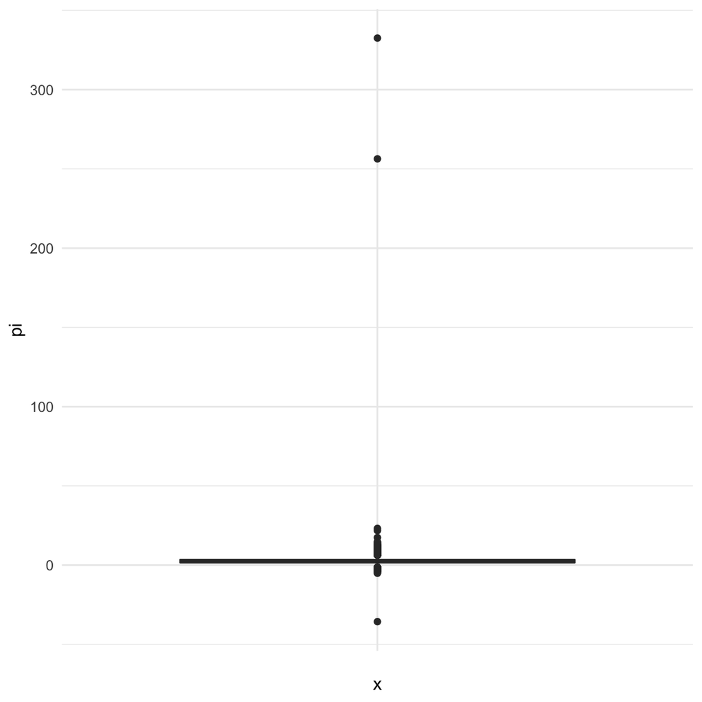

Figure 1: Boxplot depicting outliers

```r
  ggplot(statecpi_beta) +
    aes(x = "", y = pi) +
    geom_boxplot(fill = "#0c4c8a") +
    theme_minimal()
```

We see that there are three suspected outliers. Let us use the Rosen Test as the data follows approximately a normal distribution and has large number of observations.

```r
library(EnvStats)
test <- rosnerTest(statecpi_beta$pi,
    k = 3
  )
test$distribution
```

```
## [1] "Normal"
```

```r
test$sample.siz
```

```
## [1] 4699
```

```r
test$parameters
```

```
## k
## 3
```

```r
test$all.stats
```

```
##   i   Mean.i     SD.i     Value Obs.Num    R.i+1 lambda.i+1 Outlier
## 1 0 2.846148 6.434445 332.52344     594 51.23632   4.399422    TRUE
## 2 1 2.775974 4.273907 256.33800     984 59.32792   4.399375    TRUE
## 3 2 2.721990 2.139181 -35.64684    1157 17.93623   4.399328    TRUE
```

Therefore we need to remove these three outliers from our analysis.

**Summary**

Okay let’s now solve all these issues.

```r
# Let us filter out the years where 13 states do not have data.
statecpi_filtered <- statecpi_beta %>% group_by(state, year) %>% filter(year >= 1989)
# Let us add a row
cpi1989 <- statecpi_beta %>% filter(year == 1989, quarter == 1)
meancpi <- mean(cpi1989$pi)
Oklahoma_1989_1 <- data.frame(state = "Oklahoma", year = 1989, quarter = 1, pi = meancpi)
statecpi_imputed <- rbind(statecpi_filtered, Oklahoma_1989_1)
# Let us remove the outlier values mentioned in previous analysis and repeat the imputation process with the mean.
cpi256 <- statecpi_imputed %>% filter(year == 1995, quarter == 4)
meancpi256 <- mean(cpi256$pi)
cpi332 <- statecpi_imputed %>% filter(year == 2003, quarter == 2)
meancpi332 <- mean(cpi332$pi)
cpi35 <- statecpi_imputed %>%  filter(year == 2001, quarter == 1)
meancpi35 <- mean(cpi35$pi)
df <- statecpi_imputed %>%
  mutate(pi = replace(pi, pi == 332.52344, meancpi332), pi = replace(pi, pi == 256.33800, meancpi256), pi = replace(pi, pi == -35.64684, meancpi35))
summary(df)
```

```
##     state                year         quarter           pi
##  Length:3944        Min.   :1989   Min.   :1.00   Min.   :-35.647
##  Class :character   1st Qu.:1996   1st Qu.:1.75   1st Qu.:  1.496
##  Mode  :character   Median :2003   Median :2.50   Median :  2.338
##                     Mean   :2003   Mean   :2.50   Mean   :  2.327
##                     3rd Qu.:2010   3rd Qu.:3.25   3rd Qu.:  3.222
##                     Max.   :2017   Max.   :4.00   Max.   : 12.145
```

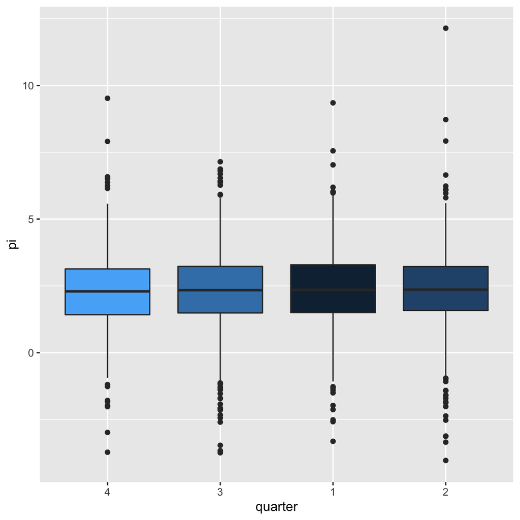

Figure 2: Boxplot depicting the median, 25th percentile and 75th percentile

```r
df %>% group_by(quarter) %>% filter(pi > -10)  %>%
  ggplot( aes(x=reorder(quarter, pi), y=pi, fill=quarter)) +
    geom_boxplot() +
    xlab("quarter") +
    theme(legend.position="none")
```

Now, we wish to ascertain if inflation dispersion has increased over time. To do this, we shall track the trend of S.D (Standard Deviation).

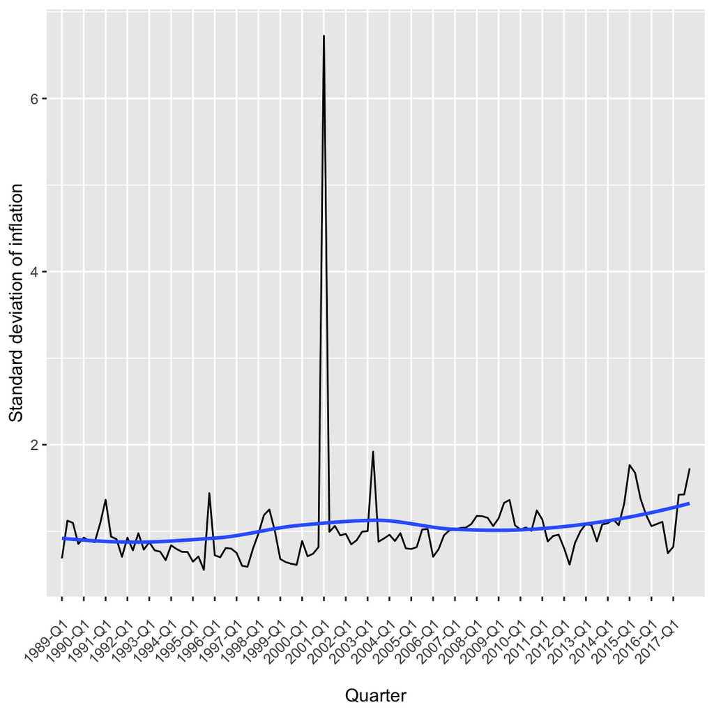

Figure: Trend of dispersion of inflation

```r
# Load necessary libraries
library(dplyr)    # For data manipulation
library(ggplot2)  # For plotting

# Calculate the standard deviation of inflation (pi) for each quarter
df %>%
  # Group the data by year and quarter, and calculate the standard deviation of pi
  group_by(year, quarter) %>%
  summarise(sd_inflation = sd(pi)) %>%
  ungroup() %>%
  # Create a new column called quarter_label, which combines the year and quarter into a single string
  mutate(quarter_label = paste0(year, "-Q", quarter)) -> sd_df

# Plot the standard deviation of inflation against quarter
ggplot(sd_df, aes(x = quarter_label, y = sd_inflation, group = 1)) +
  # Add a line connecting the data points
  geom_line() +
  # Add a smoothed trend line using a LOESS regression method
  geom_smooth(method = "loess", se = FALSE) +
  # Set the x-axis label and breaks to show every fourth quarter label, and adjust the spacing between labels
  scale_x_discrete(name = "Quarter", breaks = sd_df$quarter_label[seq(1, nrow(sd_df), 4)], expand = c(0.02, 0.5)) +
  # Set the y-axis label and plot title
  labs(y = "Standard deviation of inflation") +
  # Adjust the theme to increase the spacing between the x-axis labels
  theme(axis.text.x = element_text(angle = 45, hjust = 1, vjust = 1, margin = margin(t = 10, r = 10, b = 10, l = 10)))
```

We see that variation over time is extremely volatile and shows an slight over-all increasing trend.  
**Sub Question 3: Share of States**  
We need to calculate the share of states had inflation more than 100 basis points away from median state level inflation in Q4 of 2009.

```r
# Create a new dataframe named "df_2009Q4" that contains state-level inflation data for the 4th Quarter of 2009.
df_2009Q4 <- df %>%  filter(year == "2009", quarter == "4")
median_2009Q4 <- median(df_2009Q4$pi)

# Calculate the absolute difference between each state's inflation rate and the median inflation rate
abs_diff <- abs(df_2009Q4$pi - median_2009Q4)

# Calculate the proportion of states that had an absolute difference of more than 100 basis points from the median inflation rate
share_above_100bps <- sum(abs_diff > 0.01 * 100) / nrow(df_2009Q4)

share_above_100bps
```

```
## [1] 0.3235294
```

**Sub-Question 4: Percentage of Total Variation**  
The first question to answer is what percent of the total variation in state level inflation is due to differences across individual states?

To answer this question I can think of using ANOVA (Analysis of Variance). Analysis of variance (ANOVA) is a statistical procedure for summarizing a classical linear model—a decomposition of sum of squares into a component for each source of variation in the model—along with an associated test (the F-test) of the hypothesis that any given source of variation in the model is zero.

```r
# Fit an ANOVA model to the data
model <- aov(pi ~ state, data = df)

# Extract the sum of squares
ss <- anova(model)$"Sum Sq"

# Calculate the explained sum of squares (SSE) i.e between-groups sum of squares
sse <- ss[1]

# Calculate the residual sum of squares (SSR) i.e within-groups sum of squares
ssr <- ss[2]

# Calculate the total sum of squares (TSS)
tss <- sse + ssr

# Calculate the percentage of variation due to differences across individual states
state_variation <- sse / tss * 100

# Calculate the percentage of variation due to common changes in inflation across all states
common_variation <- ssr / tss * 100


state_variation
```

```
## [1] 2.266114
```

```r
common_variation
```

```
## [1] 97.73389
```

This test reveals that the **2.27 percent** of the total variation in state level inflation is due to differences across individual states and **97.73 percent** of total variation due to common changes in inflation across all states.  
**Sub-Question 5: Testing the Hypothesis**  
The following hypothesis must be tested:

“The persistence of inflation in the United States has been falling over time. However, declining persistence is due national and not to state level factors.”

The steps to doing that are as follows.  
**1. First, we need a measure of inflation persistence.**

The data given here is a time-series data. Therefore, using this data, inflation persistence can be measured by regressing inflation on several of its own lags and then calculate the sum of the coefficients on lagged inflation. In other words, estimate a univariate autoregressive (AR) time series model and to measure persistence as the sum of the estimated AR coefficients.

Before, we begin to define the AR model, it would be informative to descriptively analyze the time-series data, by plotting the Auto-Correlation and Partial Correlation Functions for each state.

First let us transform our panel data from long to wide from with time being the unique-identifying factor.

```r
library(reshape2)
# Group the data by year and quarter
 df %>%  group_by(year, quarter) %>%
# Create a new column called quarter_label, which combines the year and quarter into a single string
mutate(quarter_label = paste0(year, "-Q", quarter)) -> df_quarter_year
# Re-shape into wide form;
df_wide <- dcast(df_quarter_year
                  , quarter_label ~ state, value.var = "pi")
View(df_wide)
```

Okay now we have our data in wide form. After testing and correcting to ensure stationary, we should plot the acf and pacf for the 34 states. This will indicate if inflation is persistent. This will also inform us whether an AR model can be used to measure inflation persistence.

Once we do that, we can measure persistence as the summation of co-efficient of an AR model for each state.

Suppose we have a time series $Pi_t$, which we believe follows an autoregressive model of order $k$:

$$\Pi_t = \beta + \phi_1 \Pi_{t-1} + \phi_2 \Pi_{t-2} + \cdots + \phi_k \Pi_{t-k} + \epsilon_t$$

For example, we can compute an ACF and PACF chart for one state. Let us choose California.

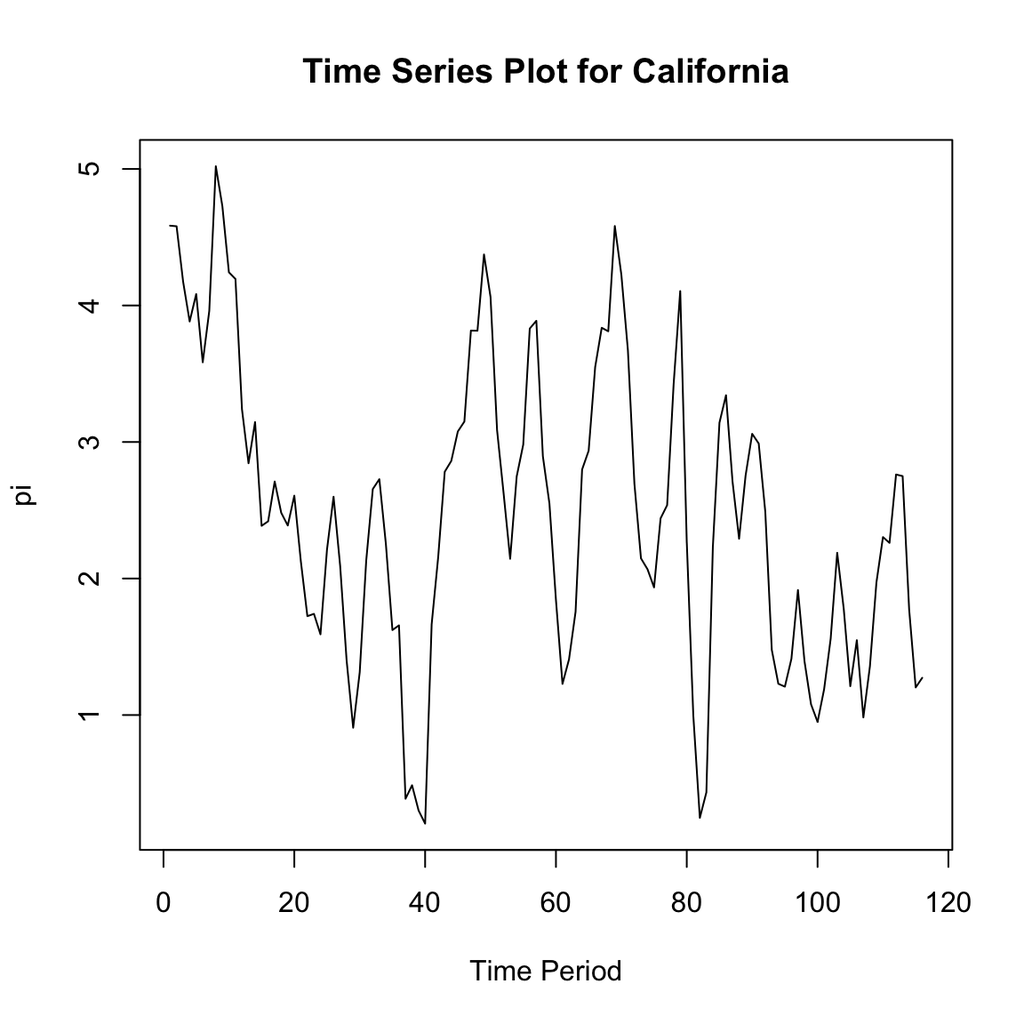

Figure 4: Time Series Plot for Inflation in California

```r
#Let us first filter out quarter-wise inflation data for California
df_california <- filter(df, state == "California")
#Let us plot the time-series graph for "df_california"
plot(df_california$pi, type = "l", xlab = "Time Period", ylab = "pi", main = "Time Series Plot for California")
```

We notice that it may be stationary. Let us check it through Augmented Dicky Fuller Test.

```r
library(tseries)
adf.test(df_california$pi)
```

```
##
##  Augmented Dickey-Fuller Test
##
## data:  df_california$pi
## Dickey-Fuller = -2.7644, Lag order = 4, p-value = 0.2593
## alternative hypothesis: stationary
```

We see that the we cannot reject the null hypothesis because the p-value is not smaller than 0.05. This indicates that the time series is non-stationary.Let us make it stationary by taking the difference in the time series vector.

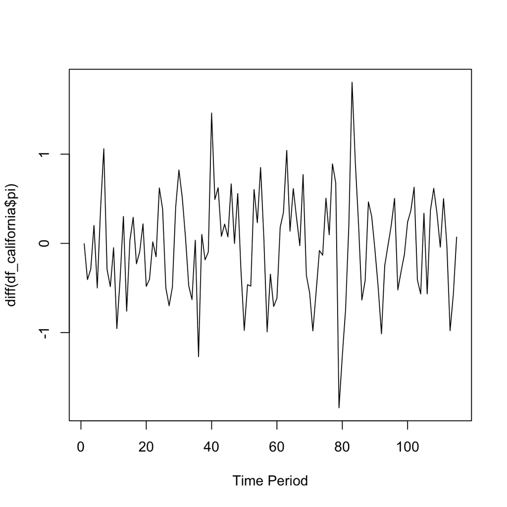

Figure 5: 1st Difference Time Series Plot for Inflation in California

```r
diff_df_california <- diff(df_california$pi)
plot(diff(df_california$pi), type = "l", xlab = "Time Period")
```

```r
adf.test(diff(df_california$pi))
```

```
##
##  Augmented Dickey-Fuller Test
##
## data:  diff(df_california$pi)
## Dickey-Fuller = -5.9695, Lag order = 4, p-value = 0.01
## alternative hypothesis: stationary
```

It is stationary now. Now let us plot the ACF and PACF for California.

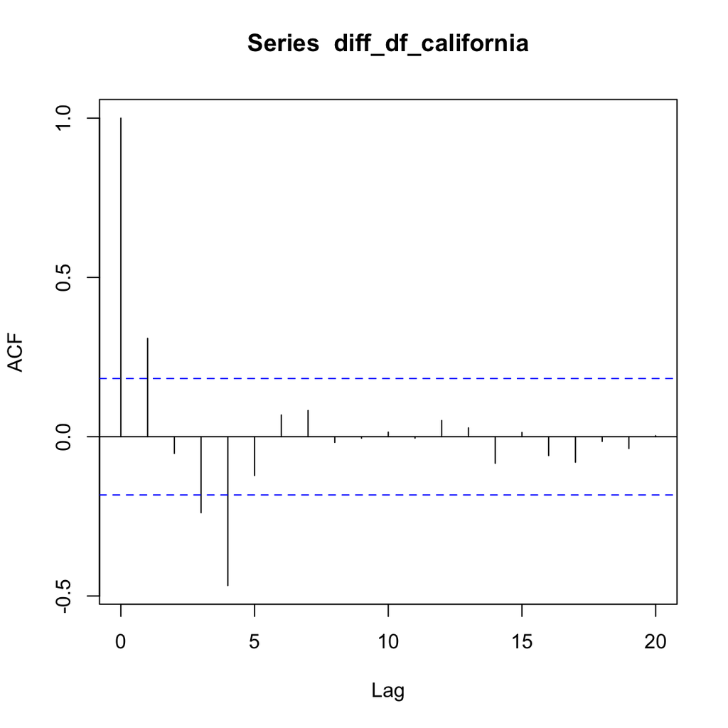

Figure 6: ACF of Time Series Plot for Inflation in California

```r
acf(diff_df_california, plot = TRUE)
```

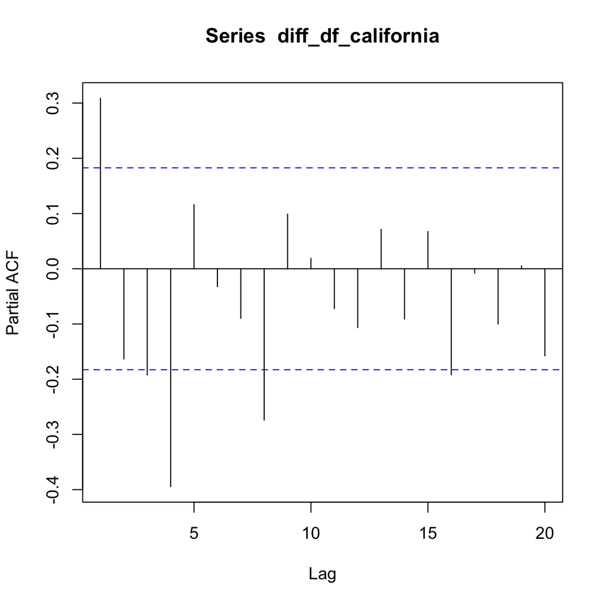

Figure 7: PACF of Time Series Plot for Inflation in California

```r
pacf(diff_df_california, plot = TRUE)
```

**2. Now we need a null hypothesis and alternate hypothesis to test if inflation persistence is indeed falling across states**

**3. If inflation persistence is falling across states, we need to determine if this fall is due to national and not state-level factors.**

*Note: I find the final question, a little beyond my knowledge. Forgive me for not seeing this question through and if I have made errors. I am still a novice at this. I shall study more and come back to this question with a better conceptual understanding. Thank You!*

**Task 2: Text to Data Analysis**

**Let us create two new columns. Namely, “City” and “State”**

To do this, we use the following script.

```r
library(readr)
library(stringr)
setwd("/Volumes/Fire/RA_Econ/Econ RA Assignments/RA_task2023_with_data")
patent <- read_csv("PatentsRawData.csv")
plant <- read_csv("PlantLocations.csv")


state <- c() # create an empty vector to store state information
city <- c() # create an empty vector to store city information
locations <- as.character(patent$inventorlocation) # Extract the "inventorlocation" column from patent and store it as characters

# Loop through each location in "locations"
for (x in 1:length(locations)) {
  tokens <- str_split(locations[x], ',')[[1]]  # Split the location string by comma and store the tokens in a list
  tokens <- str_trim(tokens) # Trim leading/trailing whitespaces from each token
  tokens <- tokens[str_length(tokens) > 1] # Extracting all tokens with more than one character

  if (length(tokens) >0) {
    state[x] <- tokens[length(tokens)] # Extract the last token as state in "State" Vector
  } else {state[x] <- -1 # If no state information found, set it to -1
  }

  if (length(tokens) >1){ # Extract the second-to-last token as city and store in 'city' vector
    city[x] <- tokens[length(tokens) - 1] # If no city information found, set it to -1
  } else {city[x] <- -1
  }

}


patent$State <- state
patent$City <- city
patent <- patent[, c("id", "company", "inventorlocation", "State", "City")]

datatable(patent, rownames = FALSE, filter="top", options = list(pageLength = 5, scrollX=T) )
```

| id | company | inventorlocation | State | City |
| --- | --- | --- | --- | --- |
| US-2573044-A | Aeronca | MECHANISM William Tudor Morris, Middletown, Ohio, | Ohio | Middletown |
| US-2521339-A | Aeronca | RCRAFT SEAT Edward R. Burn, Cuyahoga Falls, Ohio, | Ohio | Cuyahoga Falls |
| US-2601902-A | Beech | re A. Wells and Harry L. Reiter, Wichita, Kans., | Kans. | Wichita |
| US-2576867-A | Beech | Y HARNESS Leonard Lee Wilson, Jr., Wichita, Kans, | Kans | Wichita |
| US-2497957-A | Beech | WINDOW FRAIME ""P'errfH. Pelley, Wichita, Kansg; | Kansg; | Wichita |
| US-2454981-A | Beech | CRAFT CONTROL Jesse L. Vint, Jr., Wichita, Kans., | Kans. | Wichita |
| US-2432396-A | Beech | 7 AIRPLANE WING Harold W. Earhart, Wichita,Kans., | Kans. | Wichita |
| US-2793779-A | Beech | G SECTIONAL TANK Warren G. Woods, Wichita, Kans., | Kans. | Wichita |
| US-2926688-A | Beech | rd A. Muma :and John Lee Markley, Wichita, Kano, : | Kano | Wichita |
| US-2448362-A | Beech | D CONSTRUCTION Harold W. Earhart, Wichita, Kans., | Kans. | Wichita |

[output cut: 1553 more lines]

Our objective is try and match as much as possible of the **1563** unique patents to their respective places of origins (factories) using the location of residence of the inventor.

We want to match the city column of the “patent’ dataframe to city column of the”plants" dataframe. This will directly match part of the patents to the place of origin.This will ensure that part of the total patents are matched. For the rest, we can join through company, which will give us potential different factory locations.

```r
library(knitr)
library(dplyr)
# Let us first join using the city.
colnames(patent)[2] <- "Company"
patent_joined <- inner_join(patent, plant, by = c("City", "Company"))
View(patent_joined)
distinct_count_patent_joined <- patent_joined %>%
  summarize(num_distinct_items = n_distinct(id))
distinct_count_patent_joined
```

```
## # A tibble: 1 × 1
##   num_distinct_items
##                <int>
## 1                409
```

So out of 1563, we have accurately mapped 409 of patents to their factory of origin as the factory (as the factory and the inventor shared the same city) through this manoveur.

```r
# Let us find the patents in "patent" and not in "patent_joined"
patent_unmatched <- anti_join(patent, patent_joined, by = c("City", "Company"))
View(patent_unmatched)
#Rename "state.x" and "state.y" columns in "patent_joined" dataframe
colnames(patent_joined)[4] <- "state"
colnames(patent_joined)[6] <- "statefull"
patent_unmatched %>%
  summarize(num_distinct_items = n_distinct(id))
```

```
## # A tibble: 1 × 1
##   num_distinct_items
##                <int>
## 1               1154
```

So we have 1154 patents left to be matched.

Here, we notice that, in “patent_joined”’ dataframe, the abbreviated/half-spelled/mis-spelled state names from the “patent” dataframe can now be matched with to the “plant” dataframe. So through this, we can make a dictionary of the abbreviations/mis-spelled state names to their full form. This dictionary can then be used later to tidy up the “state” column of patent_unmatched and further match patent to factory of origin.

```r
#Get unique values of
state_x_unique <- unique(patent_joined$state)
# Create a dictionary to map state.x to state.y
dict <- setNames(patent_joined$statefull, patent_joined$state)
# Create a new dictionary with only distinct abbreviations
dict_distinct <- dict[state_x_unique]
# Add "N. J." = "New Jersey" as it features multiple times and wasn't in patent_joined
dict_distinct["N. J."] <- "New Jersey"
# Print the dictionary with distinct abbreviations
print(dict_distinct)
```

```
##                     Ohio                    Kans.                     Kans
##                   "Ohio"                 "Kansas"                 "Kansas"
##                   Kansg;                     Kano                     Kane
##                 "Kansas"                 "Kansas"                 "Kansas"
##                  - Kans.                    N. Y.                    Wash.
##                 "Kansas"               "New York"             "Washington"
##                     Wash        Wash; said Hudson                    Wasln
##             "Washington"             "Washington"             "Washington"
##                    Kaus.                    awash                    Wasla
##                 "Kansas"             "Washington"             "Washington"
##               =\\/Vashi;                    Washa                    Walla
##             "Washington"             "Washington"             "Washington"
##                    :Wash                      Pa.                      Ia.
##             "Washington"           "Pennsylvania"           "Pennsylvania"
##                       Pa                    Pa...                     'Pa.
##           "Pennsylvania"           "Pennsylvania"           "Pennsylvania"
##                     vPa.                      Pa"                     Pa.=
##           "Pennsylvania"           "Pennsylvania"           "Pennsylvania"
##                    Conn.                   Calif.                     Tex.
##            "Connecticut"             "California"                  "Texas"
##                    Mich. and Henry K. Gro- Calif.                     Mich
##               "Michigan"             "California"               "Michigan"
##                  Calif.'                    alif.                      Ky.
##             "California"             "California"               "Kentucky"
##                    Ohio;                      Mo.                   N. YA.
##                   "Ohio"               "Missouri"               "New York"
##                      hio                   N. "1.                    Galif
##                   "Ohio"               "New York"             "California"
##                  - Calib                       Md                      Md.
##             "California"               "Maryland"               "Maryland"
##                      h10                    .Ohio                    Calif
##                   "Ohio"                   "Ohio"             "California"
##                   Califl                    CaliL                    Calih
##             "California"             "California"             "California"
##                   Califi                     Calm                     'Md.
##             "California"             "California"               "Maryland"
##                      Md"                     Md.'                  .Calif.
##               "Maryland"               "Maryland"             "California"
##                 Calil.'.                     N. Y                     N.Y.
##             "California"               "New York"               "New York"
##                    Ind-.                   Caiif.                  Calii'.
##                "Indiana"             "California"             "California"
##                   Calif;                    N. J.
##             "California"             "New Jersey"
```

```r
# Replace abbreviations in State column with their corresponding values
 patent_unmatched$State <- ifelse(paste0(patent_unmatched$State) %in% names(dict_distinct),
                                  dict_distinct[paste0(patent_unmatched$State)],
                                  paste0(patent_unmatched$State))
 View(patent_unmatched)
```

Now we can join “patent_unmatched” to “patent” to further match specific patents to locations.

```r
#Join by State and Company
patent_joined2 <- inner_join(patent_unmatched, plant, by = c("State", "Company"))
#Rename city.x and city.y
colnames(patent_joined2)[6] <- "factory_city"
colnames(patent_joined2)[5] <- "residence_city"
View(patent_joined)
#Create a dataframe that combines all the cities a company could have factories in within a state
patent_cities <- patent_joined2 %>%
   group_by(id) %>%      summarize(Cities = paste(unique(factory_city), collapse = ", "))
#Join "patent_cities" with "patent_joined2" to give the potential cities a factory that the patent originated from could be in
patent_joined4 <- left_join(patent_joined2, patent_cities, by = "id")
View(patent_joined4)
#Let us filter out only those patents that have only one city in the "Cities" column.
patent_one_city <- patent_joined4 %>%
  filter(str_count(Cities, ",") == 0)
View(patent_one_city)
patent_one_city %>%
  summarize(num_distinct_items = n_distinct(id))
```

```
## # A tibble: 1 × 1
##   num_distinct_items
##                <int>
## 1                686
```

As seen in “patent_one_city” there are 686 distinct patent ids indicated 686 more patents have been matched to their factory of origin. So far we have matched **1095** patents. Now there are some patents that are left out while joining “patent_unmatched” and “patent_joined4”. Also there are some patents that had more than one city in “patent_joined4”

```r
#The ones that were left out of the "patent_joined4" dataframe but were in the "patent_unmatched" dataframe are
patent_unmatched2 <- anti_join(patent_unmatched, patent_joined4, by = c("State", "Company"))
View(patent_unmatched2)
```

These are hard to match either due to untidy state names or cities not corresponding to the actual cities the factories are in. Regarding the cases where the patents that had more than one city in “patent_joined4”

```r
patent_many_city <- patent_joined4 %>%
  filter(str_count(Cities, ",") >= 1)
View(patent_many_city)
patent_many_city %>%
  summarize(num_distinct_items = n_distinct(id))
```

```
## # A tibble: 1 × 1
##   num_distinct_items
##                <int>
## 1                 82
```

Then there are **82** patents whose **state of origin has been determined** but have **2 or more** possible cities of location.

So in summation we have determined the the state and city of the origin of 1095 patents and state and potential city of origin of 82 patents. This gives us a rough approximate 75.3 % of coverage.